# Bayesian Estimation of Cognitive Models

## Overview

- Introduction to Bayesian estimation and sampling
- Introduction to JAGS and rjags
- Heirarchical models
- Signal detection model for recognition confidence
- Model comparison

## Introduction to Bayesian estimation

## Purpose

- To re-allocate credibility over parameters values based on the observed data (Kruschke, 2015)
- Given the observed data, what parameter values should we most strongly believe in?
- To obtain this we need to start with a model and some *prior* expectation as to the probability of certain parameter values in this model (more on this later)

## Bayesian modeling

- \(\theta\) = parameter(s), \(y\) = observed data
- \(p(y \mid \theta)\) = the likelihood
- \(p(\theta)\) = the prior
- \(p(y)\) = probability of the data ("the evidence")

\[ p(\theta \mid y) = \frac{p(\theta)p(y \mid \theta)}{p(y)} \]

## Bayesian modeling

\(p(y)\) does not depend on the model parameters so we can omit it in favor of the *unnormalized posterior*

\[ p(\theta \mid y) \propto p(\theta)p(y \mid \theta) \]

**The posterior is proportional to the prior times the likelihood**

## MCMC sampling

## Why sample?

- \(p(\theta \mid y)\) is a *distribution* but the shape of that distribution is not always directly attainable.
- For a normal prior on the mean and a normal likelihood function the posterior distribution for the mean is also a normal distribution.
- The normal is a *congugate prior* for the normal likelihood. (The Beta distribution is conjugate for the binomial distribution).
- For complex models with multiple different priors on different parameters an analytic expression of the posterior distribution is not possible.
- In these situations sampling is needed to approximate the posterior distribution. This is what is offered by software like JAGS, BUGS, Stan etc.

## Intro to MCMC

Markov Chain Monte Carlo

- *Markov Chain* - a "memoryless" chain of events. Each step depends on the current state (e.g. parameter value) and not previous ones.
- *Monte Carlo* - Repeated random sampling

Goal of MCMC - to approximate a target distribution

## The Metropolis Algorithm

- We want to approximate \(p(\theta \mid y)\) which is proportional to the prior times the likelihood.
- The Metropolis algorithm allows us to explore the space of possible parameter values. Values are "visited" in proportion to their density under the posterior.

## The Metropolis Algorithm

1. Select a stating point in the parameter space. This is \(\theta_{\text{current}}\)
2. A move in parameter space is suggested from a *proposal distribution*. This is \(\theta_{\text{new}} = \theta_{\text{current}} + \Delta\theta\)
3. The probability that we accept the proposed move is: \(p_{\text{accept}} = \min\left(\frac{f(\theta_{\text{new}})}{f(\theta_{\text{current}})}, 1\right)\)
4. Sample a uniform number between 0 and 1. If this number is smaller than \(p_{\text{accept}}\) then we accept the proposal and \(\theta_{\text{new}}\) becomes \(\theta_{\text{current}}\) for the next step. If not we stick with the \(\theta_{\text{current}}\) we had originally.
5. Repeat steps 2-4 many times and record \(\theta_{\text{current}}\) at the begginning of each loop.

Note for our Bayesian purposes \(f(x) = p(x)p(y \mid x)\).

## The Metropolis Algorithm

Why does it work?

- If the proposed parameter value is "better"" then the current value (i.e. produces a higher posterior density) then it is *always* visited.
- If it is not better than the current value it is visited in proportion to how it compares to the current value: \(f(\theta_{\text{new}})/f(\theta_{\text{current}})\)
- Thus, values with a higher posterior density are visited more often. Running a long chain and assessing how often certain parameter values are represented gives us the posterior even if we don't know how to express its form analytically.

## Metropolis Example

- Suppose we want to estimate the mean (\(\mu\)) IQ (or some other cognitive) score of a group of participants (N = 50).
- The test is scaled to have a population standard deviation of 15 so we assume that this is known.

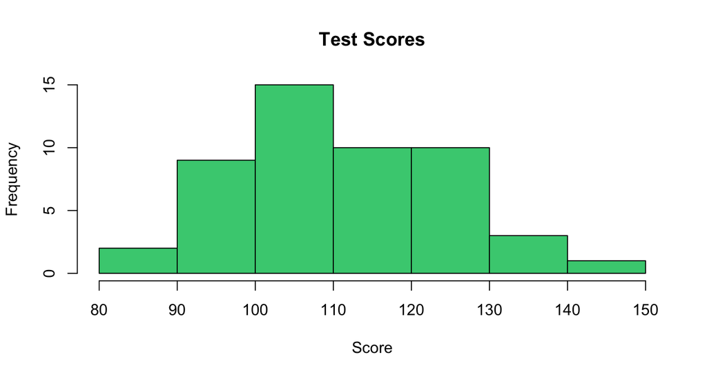

## Metropolis Example

- We need to choose a prior distribution for \(\mu\)
- Here we use a normal distribution with a mean of 100 and standard deviation of 10

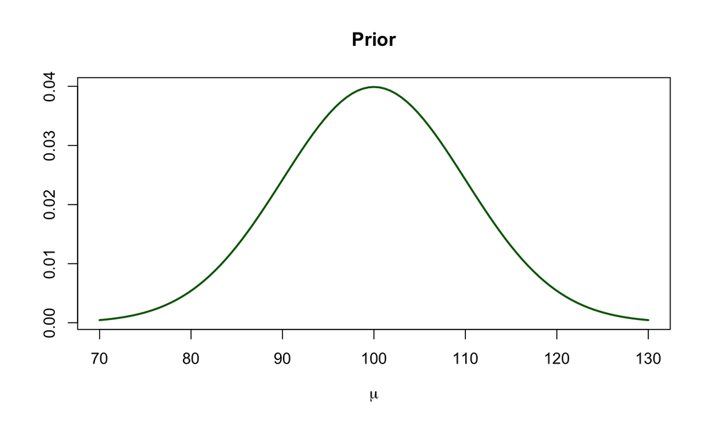

## Metropolis Example

- The script `metropolis-example.R` contains code implementing a Metropolis algoithm

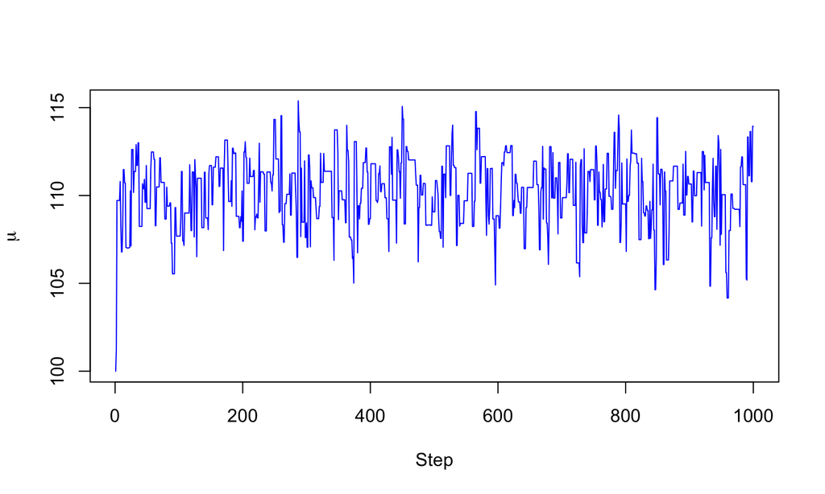

## Let's take a look at some steps

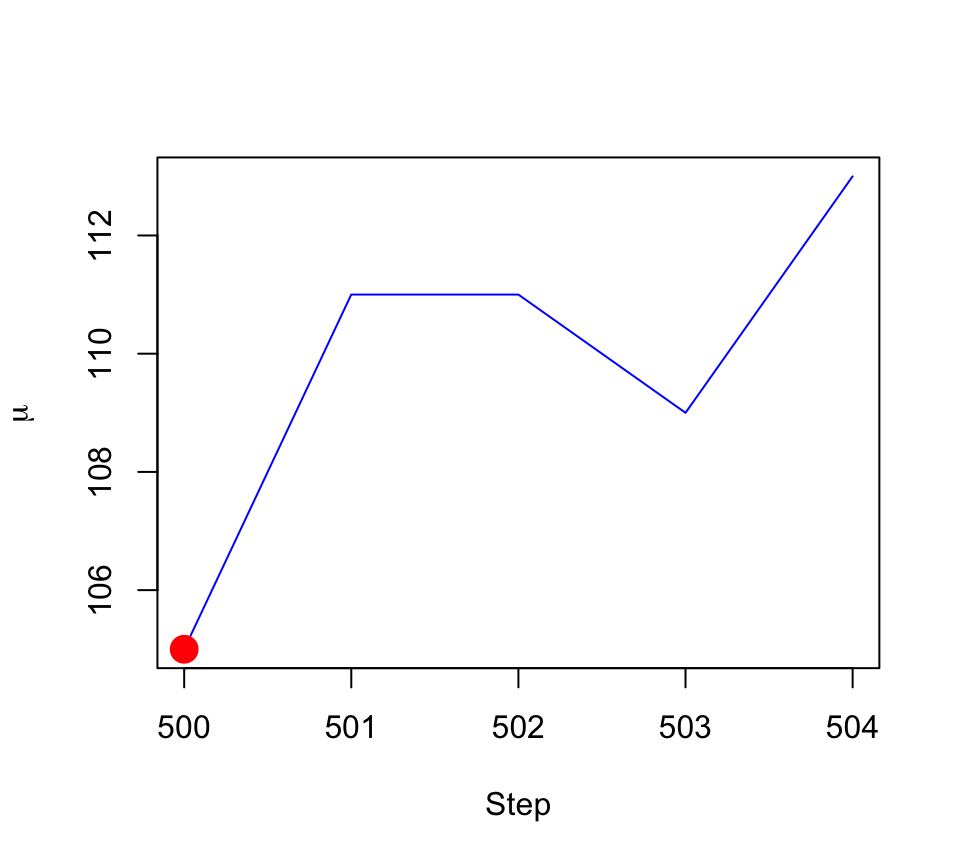

**Step 500**

- The current value of \(\mu\) is 105. A new value is proposed from a normal distribution with a mean of 105 and a standard deviation of 5. The proposed value is 111.
- Next we calculate \(p(\mu)p(y \mid \mu)\) for both the current and proposed values of \(\mu\) (we use the `dnorm` function twice as both the prior and the likelihood are normal).
- In this case \(p_{\text{accept}} = 1\) so we accept the proposal for step 501

## Let's take a look at some steps

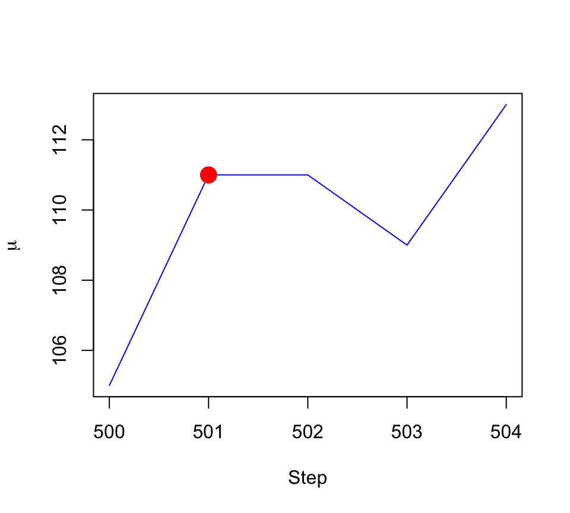

**Step 501**

- The current value of \(\mu\) is 111. The proposed value is 103.
- The ratio of \(p(\mu)p(y \mid \mu)\) for proposed relative to current value of \(\mu\) gives \(p_{\text{accept}} = .4\)
- The number sampled via `runif(n = 1, min = 0, max = 1)` is 0.6 so the proposal is *rejected*
- We stick with 111 for the next step

## Let's take a look at some steps

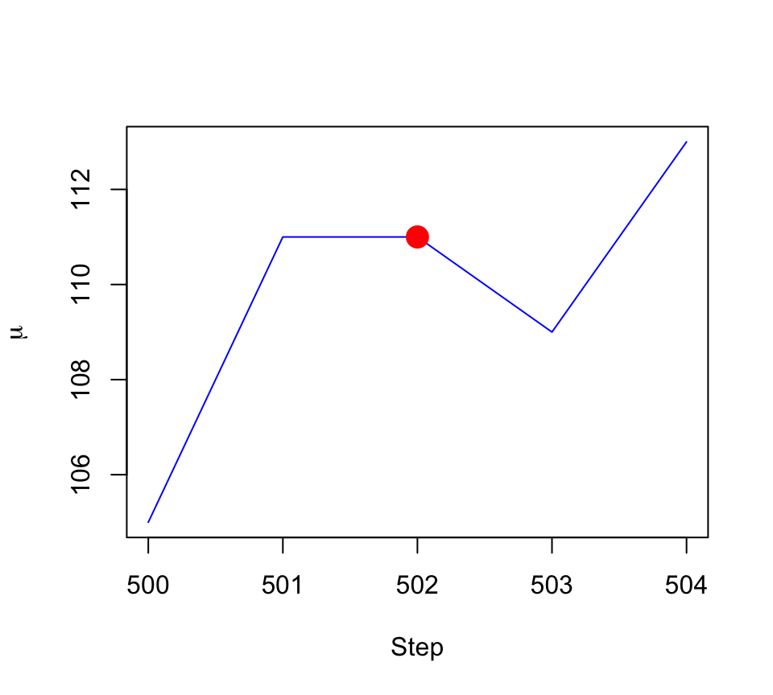

**Step 502**

- The current value of \(\mu\) is 111. The proposed value is 109.
- The ratio of \(p(\mu)p(y \mid \mu)\) for proposed relative to current value of \(\mu\) gives \(p_{\text{accept}} = .8\)
- The number sampled via `runif(n = 1, min = 0, max = 1)` is 0.34 so the proposal is *accepted*
- The current value is set to 109 for step 503.

and so on…

## It works!

For a normal likelihood with a normal prior on the mean the form of the posterior distribution is known. So we can compare the results.

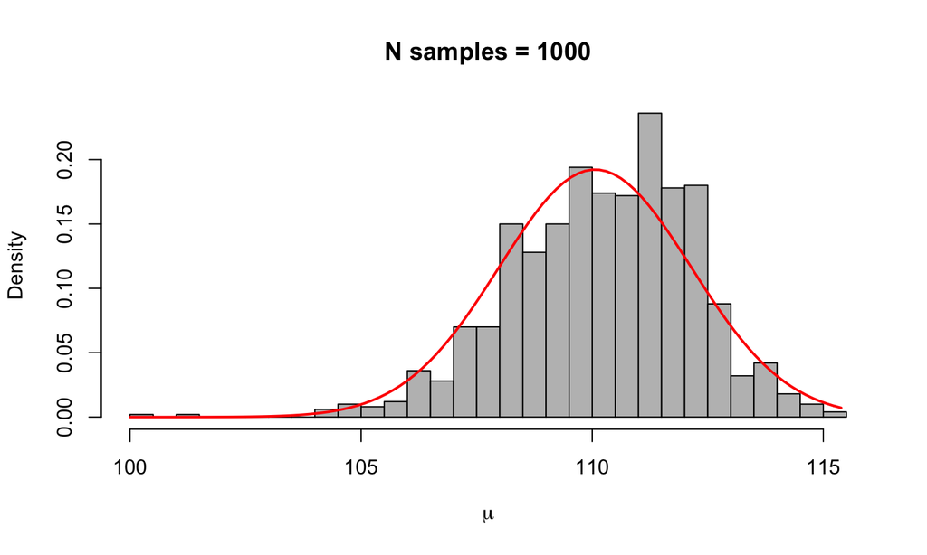

## It works!

Increasing the number of steps improves the approximation.

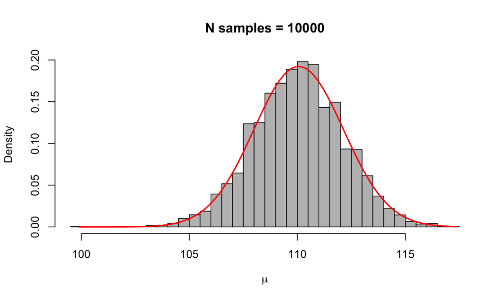

## How accurate is the MCMC chain?

## Things to consider

- Burn in (or warm up)
- Autocorrelation
- Effective Sample Size (ESS)
- Convergence and the Potential Scale Reduction Factor (PSRF)
- Thinning

## Burn in (or warm up)

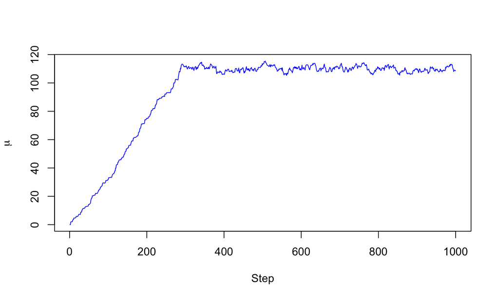

## Autocorrelation

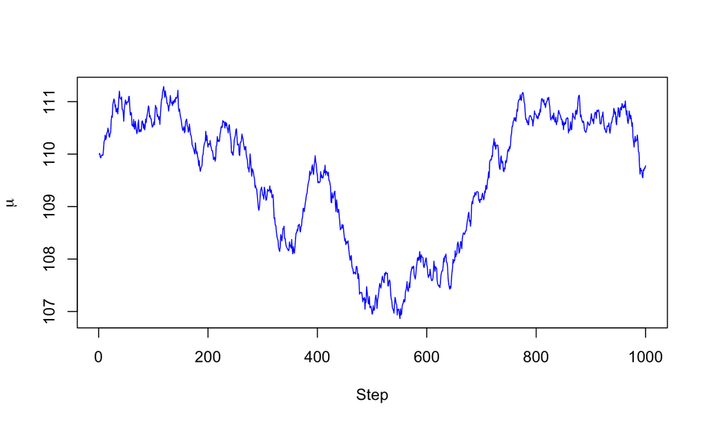

## Autocorrelation

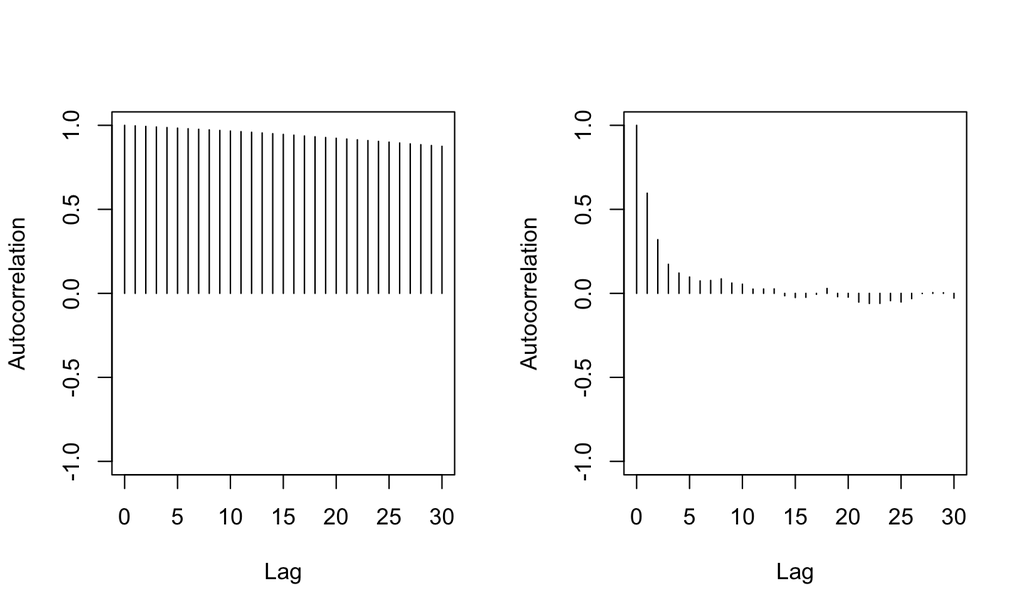

## Effective Sample Size

A way of estimating the number of independent samples once accounting for autocorrelation:

\[ ESS = \frac{N}{1 + 2\sum_{k = 1}^{\infty} \rho_k} \]

Where \(\rho_k\) is the autocorrelation at lag \(k\). Think of this as dividing the number of samples by the amount of autocorrelation. In practice the sum stops when the autocorrelation is small (e.g. \(\rho_k < 0.05\); see Kruschke, 2015, p. 184).

## Convergence

How do we know that we have converged onto a stable distribution?

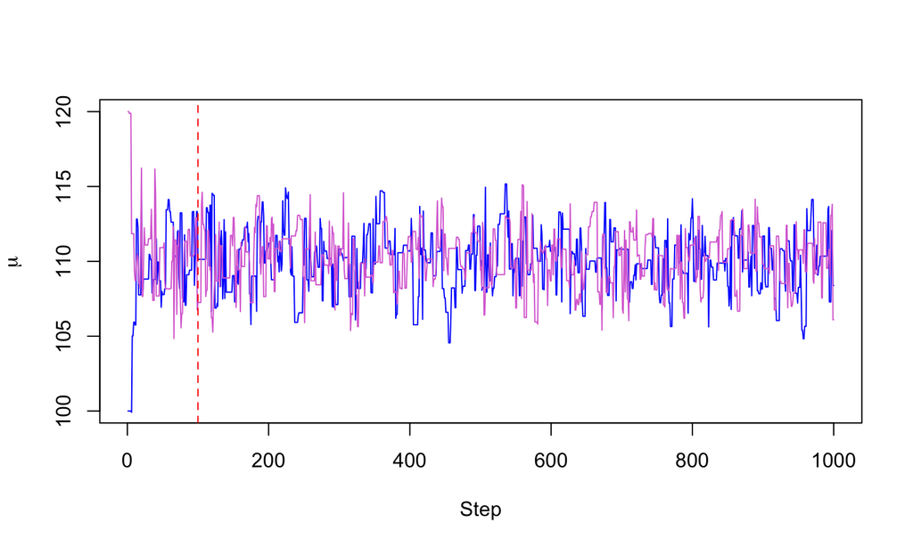

## Convergence

- Run multiple sequences (*chains*) with different starting points
- Compare variation between different chains to variation within chains. When these are approximately equal we can claim to have converged on the target distribution.
- This is measured via \(\hat{R}\) and convetionally a value \(< 1.1\) is considered converged.
- \(\hat{R}\) is also refered to as the Gelman-Rubin convergence diagnostic or the Potential Scale Reduction Factor (PSRF).

## Convergence

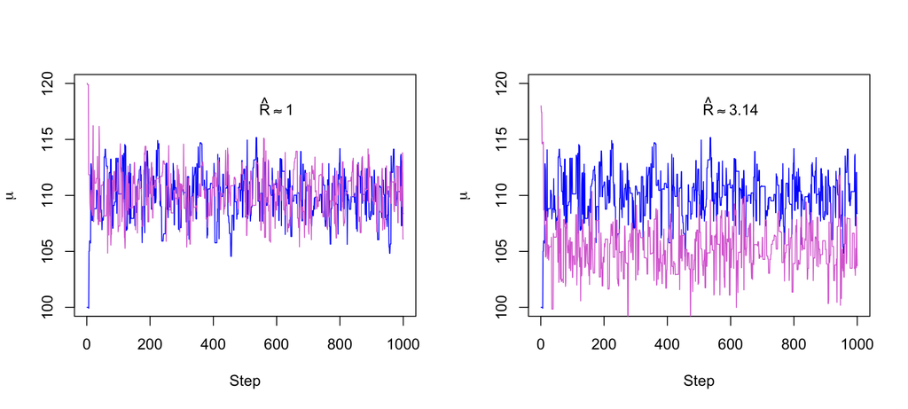

## Thinning

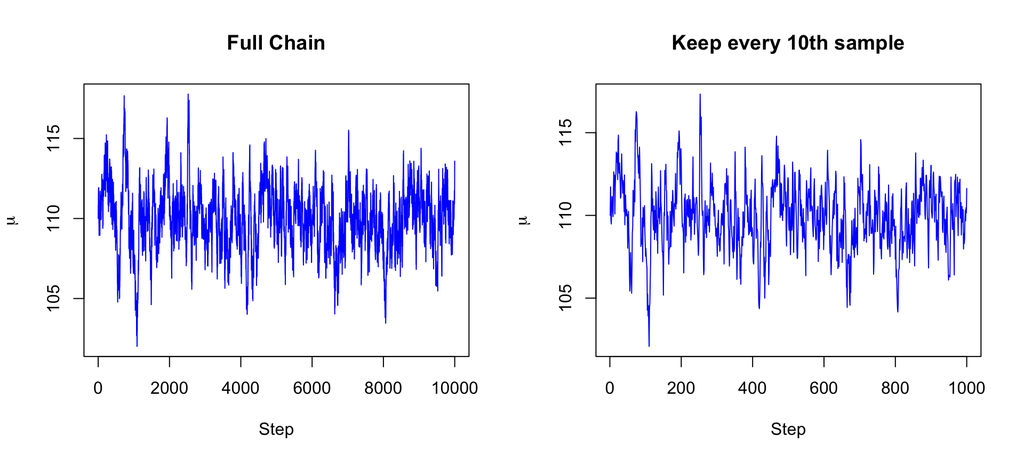

## Thinning

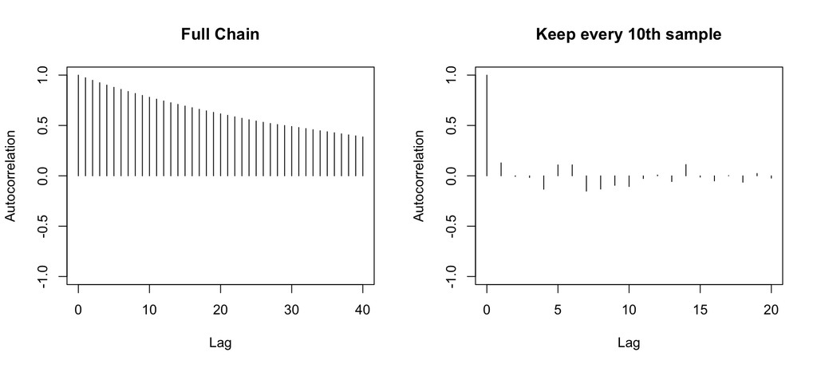

## Thinning

- If autocorrelation is really bad thinning might help, but it might suggest deeper problems with your model (see Gelman et al., 2014)
- It has been claimed that thinning is "often unnecessary and always inefficient" ([Link & Eaton, 2012](https://besjournals.onlinelibrary.wiley.com/doi/full/10.1111/j.2041-210X.2011.00131.x)).
- Often it is better to keep the full chains than throw information away.

## Gibbs Sampling

## Reminder of the Metropolis algorithm

1. Select a stating point in the parameter space.
2. A move in parameter space is suggested from a *proposal distribution*.
3. We work out the probability of accepting the move via \(p_{\text{accept}} = \min\left(\frac{f(\theta_{\text{new}})}{f(\theta_{\text{current}})}, 1\right)\).
4. If a uniform(0, 1) number is smaller than \(p_{\text{accept}}\) then we accept the new parameter value for the next cycle.
5. Repeat steps 2-4 many times.

## Gibbs Sampling

More complicated than our Metropolis algorithm but better for large numbers of parameters, which easily occurs in hierarchical modeling. Imagine a two parameter situation \(\{\theta_1, \theta_2\}\) with independent prior distributions \(p(\theta_1, \theta_2) = p(\theta_1)p(\theta_2)\).

1. Start at a random point in the (two dimensional) parameter space.
2. Select one of the parameters (e.g. \(\theta_1\)). Sample a new value for it from \(p(\theta_1 \mid \theta_2, y)\) using the current value of the other parameters (in this case, \(\theta_2\)).
3. The sampled value comes directly from the posterior of \(\theta_1\) conditional on the current value of \(\theta_2\) so the move is *always* accepted.
4. Go back to step 2 and repeat many times.

To do this we need to know the conditional distributions for each parameter given each of the others \(p(\theta_i \mid \theta_{i \neq j}, y)\). Luckily software (JAGS) can do this for us!

## End of the introduction to sampling

This drew heavily on:

- Kruschke (2015). Doing Bayesian Data Analysis: A Tutorial with R, JAGS, and Stan. Chapter 7.
- Gelman et al. (2014). Bayesian Data Analysis (3rd edition). Chapters 11 and 12.

## JAGS and rjags

## What is JAGS?

- Just Another Gibbs Sampler ([Plummer, 2003](https://www.r-project.org/conferences/DSC-2003/Proceedings/Plummer.pdf), [user manual](https://sourceforge.net/projects/mcmc-jags/files/Manuals/4.x/jags_user_manual.pdf/download))
- Samples from the posterior distribution for you!
- Preceded by BUGS ([Lunn et al., 2009](https://wiki.helsinki.fi/download/attachments/59060372/BUGSproject.pdf)) and uses a similar model language.
- `rjags` ([Plummer, 2016](https://cran.r-project.org/web/packages/rjags/rjags.pdf)) allows R and JAGS to work together.

## Basic JAGS Model

```r
model {
  for (i in 1:N){
  # likelihood
  }
  # priors
}
```

## Basic JAGS Model

For our IQ example:

```r
model {
  for (i in 1:N){
  # likelihood
    y[i] ~ dnorm(mu, 1/15^2) # normal likelihood with known SD of 15
  }
  # prior
  mu ~ dnorm(prior_m, 1/prior_sd^2) # normal prior on mu

  prior_m <- 100
  prior_sd <- 10
}
```

## Some things to note

- JAGS works with *precision* (often denoted \(\tau\)) rather than standard deviation (\(\tau = 1/\sigma^2\))
- Variables with a distribution are assigned with `~`
- Deterministic relations are assigned with `<-`

## Basic rjags

`rjags-basics.R` shows how to run this basic model with `rjags`

- The model is saved as a string (or can be a separate .txt file)
- `jags.model` creates the graphical model and tunes the sampler. Here we specify how many chains we want.
- `update` is used to warm up the model (these samples are not kept)
- `coda.samples` returns `n.iter` samples per chain. Returns an `mcmc.list` object.

## Basic rjags

```r
# put the data in a list
data_list = list('y' = Y,
            'N' = N)

# create the jags model
jags <- jags.model(file = textConnection(model),
                   data = data_list,
                   n.chains = 4,
                   n.adapt = 1000)

# warm up/ burn in
update(jags, 1000)

# run the samples
samples = coda.samples(model = jags,
                       variable.names = "mu",
                       n.iter = 1000)
```

## Basic rjags/ coda

With the `samples` `mcmc.list` we can use the `coda` package to look at our samples.

## Basic rjags/ coda

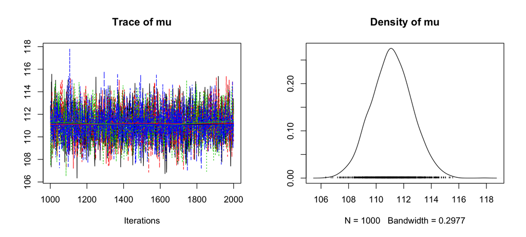

```r
plot(samples)
```

## Basic rjags/ coda

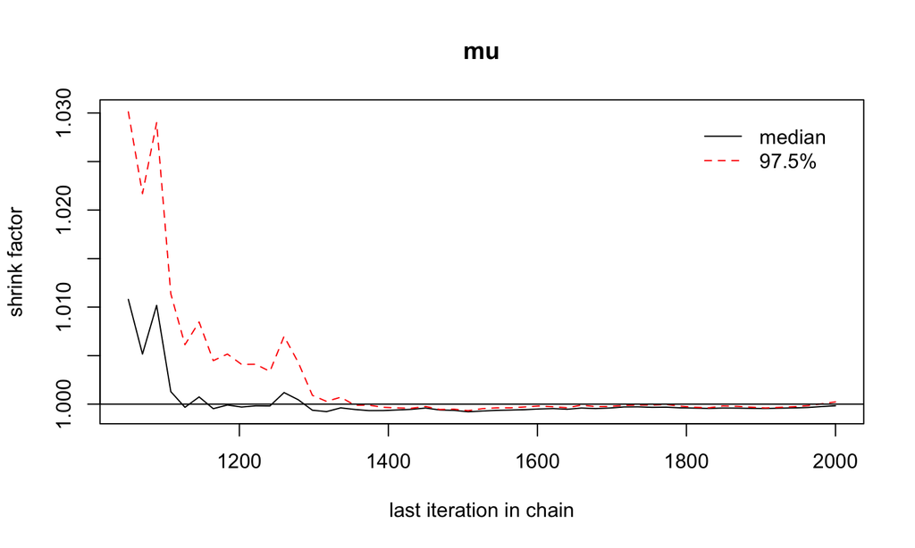

```r
gelman.plot(samples)
```

## Basic rjags/ coda

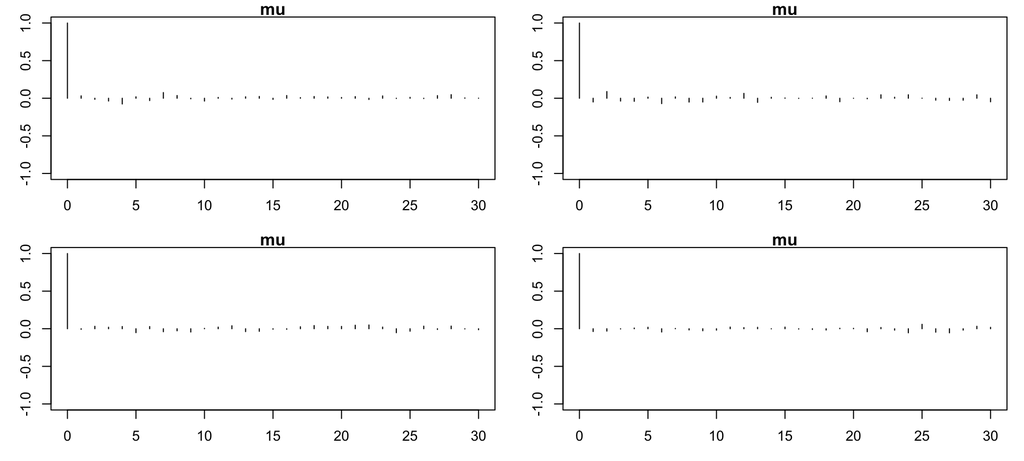

```r
par(mfrow=c(2,2), mar=c(3,3,1,1))
autocorr.plot(samples, auto.layout = F)
```